# Fit data and plot results - MLE and MLEbin methods

### Determine $x_{min}$ for MLEbin method when the data are not simply declining

Similar to the example above for a vector of values, we can determine a value of $x_{min}$ to use for the MLEbin method if the data look non-decreasing.

For a mock dataset we can just use the above `mock_data` and then bin the values with bin widths that double in size, using the `bin_data` function:

```r
mock_binned <- bin_data(mock_data,
                        bin_width = "2k")$bin_vals %>%
                 dplyr::select(bin_min,
                               bin_max,
                               bin_count)
mock_binned
  # A tibble: 9 × 3
    bin_min bin_max bin_count
      <dbl>   <dbl>     <int>
  1    0.25     0.5        15
  2    0.5      1          23
  3    1        2          62
  4    2        4         538
  5    4        8         233
  6    8       16         116
  7   16       32          79
  8   32       64          26
  9   64      128           8
```

Now use the explicit fitting function:

```r
res_mock_binned <- determine_xmin_and_fit_mlebin(mock_binned)
```

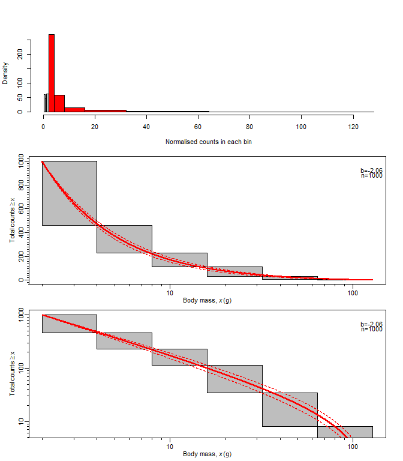

```r
plot(res_mock_binned)
```

The red bars in the histogram show the values that are used to fit the PLB distribution, with $x_{min}$ being the lowest bin break of the lowest red bin; note the three grey bins that are not used for the fitting. This histogram shows the density in each bin, not the counts, because the bin widths are not equal; density is the count in a bin divided by the bin width.

```r
res_mock_binned
  $mlebin_fit
  $b_mle
  [1] -2.061935

  $b_conf
  [1] -2.141015 -1.985265

  $data
  # A tibble: 6 × 6
    bin_min bin_max bin_count count_gte_bin_min low_count high_count
      <dbl>   <dbl>     <int>             <int>     <int>      <int>
  1       2       4       538              1000       462       1000
  2       4       8       233               462       229        462
  3       8      16       116               229       113        229
  4      16      32        79               113        34        113
  5      32      64        26                34         8         34
  6      64     128         8                 8         0          8

  $x_min
  [1] 2

  $x_max
  [1] 128

  $method
  [1] "MLEbin"

  attr(,"class")
  [1] "size_spectrum_mlebin" "list"

  $h
  $breaks
   [1]   0.25   0.50   1.00   2.00   4.00   8.00  16.00  32.00  64.00 128.00

  $mids
  [1]  0.375  0.750  1.500  3.000  6.000 12.000 24.000 48.000 96.000

  $counts
  [1]  15  23  62 538 233 116  79  26   8

  $density
  [1]  60.0000  46.0000  62.0000 269.0000  58.2500  14.5000   4.9375   0.8125   0.1250

  $xname
  [1] "Normalised counts in each bin"

  $equidist
  [1] FALSE

  attr(,"class")
  [1] "histogram"

  attr(,"class")
  [1] "determine_xmin_and_fit_mlebin" "list"
```

The `res_mock_binned` object is list of two objects:

- `$mlebin_fit`: contains the MLEbin results as in the simpler example above
- `$h`: the histogram results as used for calculating $x_{min}$ and for plotting.

The object is of class `determine_xmin_and_fit_mlebin`, and so the plotting function `plot.determine_xmin_and_fit_mlebin()` is automatically used by `plot(res_mock_binned)` to give the above plot.

And then also consider that we want to also allow for a tibble that has year or another heading (maybe allow it to be called strata, or let user add that as an option - yes, strata = year as the default, or maybe strata = NULL is the default).

Our [MEE paper](http://onlinelibrary.wiley.com/doi/10.1111/2041-210X.12641/full)

Our [MEPS paper](https://www.int-res.com/abstracts/meps/v636/p19-33/)

## Session information

```r
sessionInfo()
  R version 4.5.1 (2025-06-13 ucrt)
  Platform: x86_64-w64-mingw32/x64
  Running under: Windows 11 x64 (build 22631)

  Matrix products: default
    LAPACK version 3.12.1

  locale:
  [1] LC_COLLATE=English_United States.utf8  LC_CTYPE=English_United States.utf8
  [3] LC_MONETARY=English_United States.utf8 LC_NUMERIC=C
  [5] LC_TIME=English_United States.utf8

  time zone: America/Vancouver
  tzcode source: internal

  attached base packages:
  [1] stats     graphics  grDevices utils     datasets  methods   base

  other attached packages:
  [1] sizeSpectraFit_0.0.99 testthat_3.2.3        devtools_2.4.5
  [4] usethis_3.2.1

  loaded via a namespace (and not attached):
   [1] generics_0.1.4    sass_0.4.10       digest_0.6.39     magrittr_2.0.4
   [5] evaluate_1.0.5    pkgload_1.4.1     fastmap_1.2.0     jsonlite_2.0.0
   [9] processx_3.8.6    pkgbuild_1.4.8    sessioninfo_1.2.3 brio_1.1.5
  [13] urlchecker_1.0.1  ps_1.9.1          promises_1.5.0    purrr_1.2.0
  [17] jquerylib_0.1.4   cli_3.6.5         shiny_1.12.1      rlang_1.1.6
  [21] ellipsis_0.3.2    withr_3.0.2       remotes_2.5.0     cachem_1.1.0
  [25] yaml_2.3.12       otel_0.2.0        tools_4.5.1       memoise_2.0.1
  [29] dplyr_1.1.4       httpuv_1.6.16     curl_7.0.0        vctrs_0.6.5
  [33] R6_2.6.1          mime_0.13         lifecycle_1.0.4   fs_1.6.6
  [37] htmlwidgets_1.6.4 miniUI_0.1.2      pkgconfig_2.0.3   desc_1.4.3
  [41] callr_3.7.6       pillar_1.11.1     bslib_0.9.0       later_1.4.4
  [45] glue_1.8.0        profvis_0.4.0     Rcpp_1.1.0        tidyselect_1.2.1
  [49] xfun_0.55         tibble_3.3.0      knitr_1.51        xtable_1.8-4
  [53] htmltools_0.5.9   rmarkdown_2.30    compiler_4.5.1
```